# Assignment 2

Patrick

9/2/2019

Install the Tidyverse

We begin by installing packages for easy data frame and date manipulation.

```r
library("tidyverse")
library("lubridate")
```

## Loading and preprocessing the data

### 1. Load the data (i.e. read.csv())

Reference the Github pages containing the activity.zip file. The URL comes directly from [Dr. Peng’s github repo](https://github.com/rdpeng/RepData_PeerAssessment1/blob/master/activity.zip) related to this assignment.

```r
datasource <-"https://github.com/rdpeng/RepData_PeerAssessment1/raw/master/activity.zip"
temp <- tempfile()
download.file(datasource, temp, mode = "wb")
unzip(temp, "activity.csv")
activity<-read.csv("activity.csv")
```

### 2. Process/transform the data into a format suitable for your analysis

Use functions native to lubridate to cast activity date to a date from a factor.

```r
activity$date <- ymd(activity$date)
activity$weekday <- wday(activity$date, label = T)
activity$year <- year(activity$date)
activity$month <- month(activity$date)
activity$day <- day(activity$date)
activity$week<-week(activity$date)
activity$weekend<-as.factor(ifelse(activity$weekday %in% c("Sat", "Sun"), "weekend", "weekday"))
```

## What is mean total number of steps taken per day?

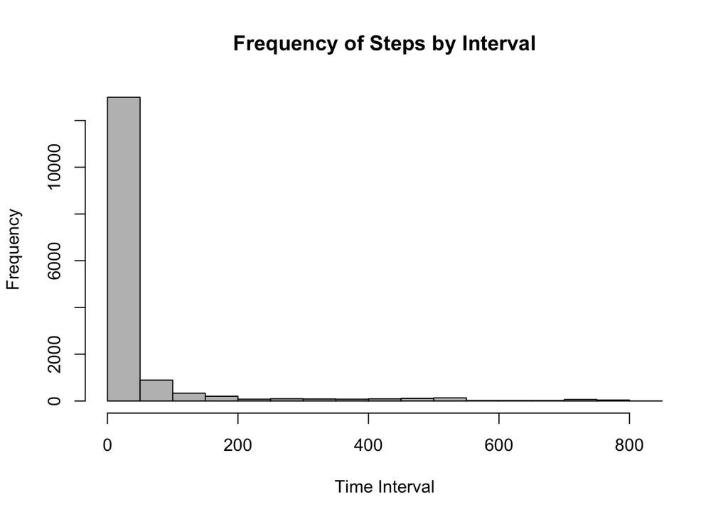

```r
hist(activity$steps,  breaks=20, col="gray", xlab="Time Interval", main="Frequency of Steps by Interval")
```

### 2. Calculate and report the mean and median total number of steps taken per day

We see in our summary below that the **mean** number of steps is **37** and the **median** is **0**.

```r
summary(activity)
```

```
##      steps             date               interval      weekday
##  Min.   :  0.00   Min.   :2012-10-01   Min.   :   0.0   Sun:2304
##  1st Qu.:  0.00   1st Qu.:2012-10-16   1st Qu.: 588.8   Mon:2592
##  Median :  0.00   Median :2012-10-31   Median :1177.5   Tue:2592
##  Mean   : 37.38   Mean   :2012-10-31   Mean   :1177.5   Wed:2592
##  3rd Qu.: 12.00   3rd Qu.:2012-11-15   3rd Qu.:1766.2   Thu:2592
##  Max.   :806.00   Max.   :2012-11-30   Max.   :2355.0   Fri:2592
##  NA's   :2304                                           Sat:2304
##       year          month            day             week
##  Min.   :2012   Min.   :10.00   Min.   : 1.00   Min.   :40
##  1st Qu.:2012   1st Qu.:10.00   1st Qu.: 8.00   1st Qu.:42
##  Median :2012   Median :10.00   Median :16.00   Median :44
##  Mean   :2012   Mean   :10.49   Mean   :15.75   Mean   :44
##  3rd Qu.:2012   3rd Qu.:11.00   3rd Qu.:23.00   3rd Qu.:46
##  Max.   :2012   Max.   :11.00   Max.   :31.00   Max.   :48
##
##     weekend
##  weekday:12960
##  weekend: 4608
##
##
##
##
##
```

## What is the average daily activity pattern?

### 1. Make a time series plot of the 5-minute interval (x-axis) and the average number of steps taken, averaged across all days (y-axis)

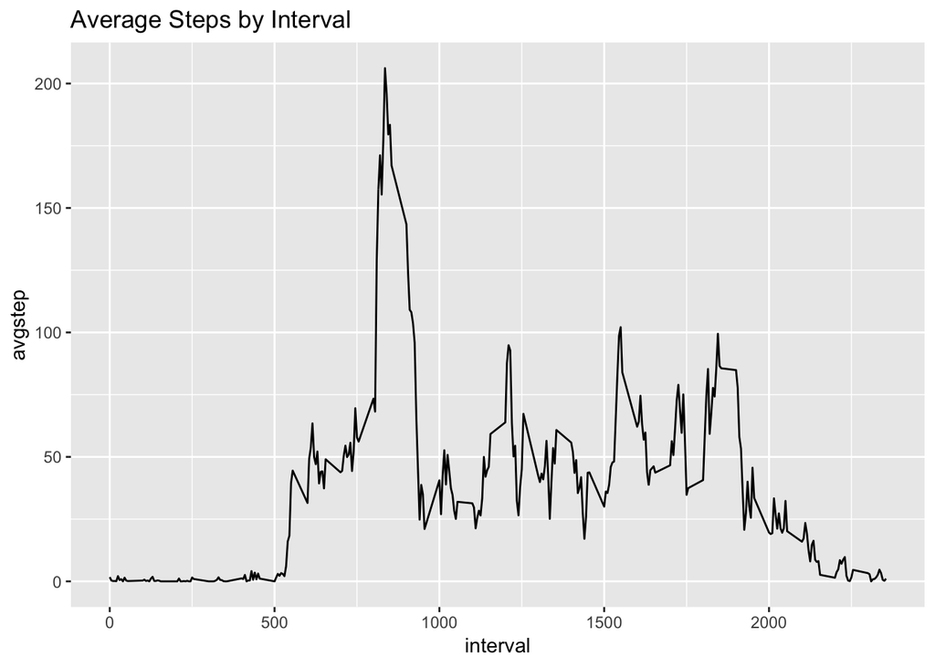

```r
activity %>%
  group_by(interval) %>%
  summarise(avgstep = mean(steps, na.rm = T)) %>%
  ggplot(., aes(x = interval, y = avgstep)) + geom_line(stat = "identity") +
  ggtitle("Average Steps by Interval")
```

### 2. Which 5-minute interval, on average across all the days in the dataset, contains the maximum number of steps?

```r
activity %>%
  group_by(interval) %>%
  summarise(avgstep = mean(steps, na.rm = T)) %>%
  arrange(desc(avgstep)) %>%
  head(., n = 1)
```

```
## # A tibble: 1 x 2
##   interval avgstep
##      <int>   <dbl>
## 1      835    206.
```

## Perform Mean Imputation on Missing Values

### 1. Calculate and report the total number of missing values in the dataset

```r
sum(is.na(activity$steps))
```

```
## [1] 2304
```

### 2. Create a new dataset using mean imputation

```r
imputed.activity<-activity %>%
  group_by(interval) %>%
  mutate(steps = replace(steps, is.na(steps), mean(steps, na.rm=T)))
```

### 3. Create a historgram and report the new mean/median of dataset with imputed values.

We observe there is no difference in the mean or median of the imputed dataset compared to the original.

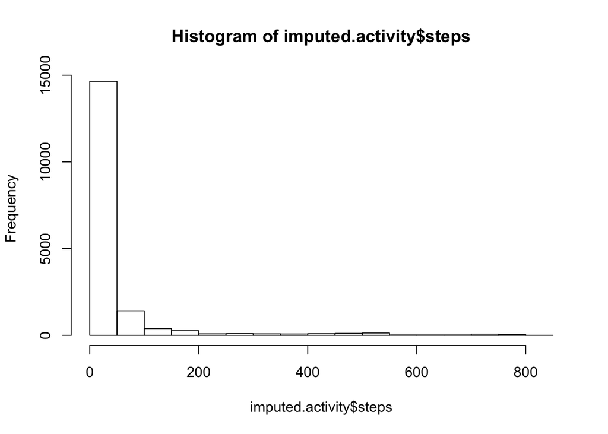

```r
hist(imputed.activity$steps)
```

```r
mean(imputed.activity$steps)
```

```
## [1] 37.3826
```

```r
median(imputed.activity$steps)
```

```
## [1] 0
```

```r
summary(imputed.activity)
```

```
##      steps             date               interval      weekday
##  Min.   :  0.00   Min.   :2012-10-01   Min.   :   0.0   Sun:2304
##  1st Qu.:  0.00   1st Qu.:2012-10-16   1st Qu.: 588.8   Mon:2592
##  Median :  0.00   Median :2012-10-31   Median :1177.5   Tue:2592
##  Mean   : 37.38   Mean   :2012-10-31   Mean   :1177.5   Wed:2592
##  3rd Qu.: 27.00   3rd Qu.:2012-11-15   3rd Qu.:1766.2   Thu:2592
##  Max.   :806.00   Max.   :2012-11-30   Max.   :2355.0   Fri:2592
##                                                         Sat:2304
##       year          month            day             week
##  Min.   :2012   Min.   :10.00   Min.   : 1.00   Min.   :40
##  1st Qu.:2012   1st Qu.:10.00   1st Qu.: 8.00   1st Qu.:42
##  Median :2012   Median :10.00   Median :16.00   Median :44
##  Mean   :2012   Mean   :10.49   Mean   :15.75   Mean   :44
##  3rd Qu.:2012   3rd Qu.:11.00   3rd Qu.:23.00   3rd Qu.:46
##  Max.   :2012   Max.   :11.00   Max.   :31.00   Max.   :48
##
##     weekend
##  weekday:12960
##  weekend: 4608
##
##
##
##
##
```

## Are there differences in activity patterns between weekdays and weekends?

### 1. Visualize new weekdays variable.

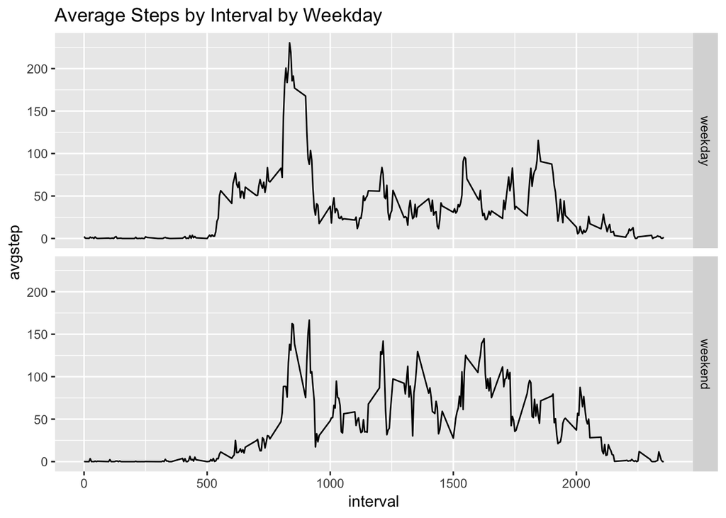

```r
imputed.activity %>%
  group_by(interval, weekend) %>%
  summarise(avgstep = mean(steps, na.rm = T)) %>%
  ggplot(., aes(x = interval, y = avgstep, group=weekend)) + geom_line(stat = "identity") +
  facet_grid(weekend ~.) +
  ggtitle("Average Steps by Interval by Weekday")
```